# Auto Immune NLP Word Associations

Janis Corona

12/6/2019

## This accompanying file ‘AutoimmuneTwitterAI-Disease-Treatments.csv’

This script will preprocess and put the diseases into groups by disease, then it will create what disease it is categorized, remove the disease name from the twitter comment, and create a target variable to use ML on to classify if the tweet is one of those types of diseases.

## Further NLP work will be done in python 3 to classify the disease and

return the probability of the tweet being one of those above diseases.

## Read in the initial Twitter scraped file of tweets on autoimmune diseases selected

## Preprocessing

cleaning up the text of characters and stemming the words, removing stopwords and special characters

```r
library(tm)
library(SnowballC)
library(wordcloud)
library(ggplot2)
```

```r
celiac <- Corpus(DirSource("Celiac1"))


celiac
```

```
## <<SimpleCorpus>>
## Metadata:  corpus specific: 1, document level (indexed): 0
## Content:  documents: 50
```

```r
celiac <- tm_map(celiac, removePunctuation)
celiac <- tm_map(celiac, removeNumbers)
celiac <- tm_map(celiac, tolower)
celiac <- tm_map(celiac, removeWords, stopwords("english"))
celiac <- tm_map(celiac, stripWhitespace)
celiac <- tm_map(celiac, stemDocument)
```

## Another way is to use a root word based on the word being an adj.,n.,v.

called lemmatization, but this uses a vector as in the original data table that was split into a corpus of text documents, the text mining package tm relies on a corpus of documents to clean the files, and python 3’s UTF=8 format won’t read in some characters in the AutoImmuneUNKNOWN.csv file that was built.

ex:

library(textstem)

celiac1 <- lemmatize_strings(Auto$Celiac, dictionary=lexicon::hash_lemmas)

## Create the document term matrix (dtm) for this corpus of Celiac Disease tweets

```r
dtmCeliac <- DocumentTermMatrix(celiac)
dtmCeliac
```

```
## <<DocumentTermMatrix (documents: 50, terms: 632)>>
## Non-/sparse entries: 1054/30546
## Sparsity           : 97%
## Maximal term length: 83
## Weighting          : term frequency (tf)
```

## order the frequencies of each word and store the frequencies and ordered values

```r
freq <- colSums(as.matrix(dtmCeliac))
```

# Replace the UNKNOWN with the disease name dn

```r
dn <- 'celiac'

unk <- grep('unknown', names(freq))
names(freq)[unk]
```

```
##  [1] "unknown"
##  [2] "unknownresearch"
##  [3] "unknowndiseas"
##  [4] "httpbeyondunknownorg"
##  [5] "httpscureunknowndiseaseorg"
##  [6] "httpunknowncom"
##  [7] "unknowncom"
##  [8] "beyondunknown"
##  [9] "unknownproject"
## [10] "unknowndoc"
## [11] "unknowndotorg"
## [12] "ihttpswwwfiercebiotechcombiotechtakedapicksupcoursunknowntreatmentpromisingmbiobuck"
## [13] "unknownrel"
## [14] "httpssupportbeyondunknownorgg"
## [15] "coeunknown"
## [16] "httpsbeepollenbuzzcombeepollenandpropolisforunknowndiseasehtml"
## [17] "calunknown"
## [18] "httpsmeatrightorgunknowndiseas"
## [19] "unknowndiari"
## [20] "canadianunknownassoc"
## [21] "ccaunknown"
## [22] "unknownsafeeat"
## [23] "unknownsma"
```

```r
names(freq)[unk[1]] <- dn
length(names(freq))
```

```
## [1] 632
```

```r
head(names(freq))
```

```
## [1] "center" "dedic"  "diseas" "disord" "gluten" "improv"
```

```r
tail(names(freq))
```

```
## [1] "indic"        "level"        "run"          "vicki"
## [5] "vvanblaricum" "’s"
```

```r
FREQ <- data.frame(freq)
ord <- order(freq, decreasing=TRUE)
head(FREQ)
```

```
##        freq
## center    3
## dedic     1
## diseas   41
## disord    3
## gluten   19
## improv    1
```

```r
grep('celiac',names(freq))
```

```
## [1] 14
```

## The dtmCeliac colnames for ‘unknown’ has to be changed to dn

```r
colnames(dtmCeliac)[unk[1]] <- dn
findAssocs(dtmCeliac, dn, corlimit=0.7)
```

```
## $celiac
##                  backtoschool                      campaign
##                          0.72                          0.72
##                           day                        gfdiet
##                          0.72                          0.72
## httpssupportbeyondunknownorgg                          imag
##                          0.72                          0.72
##                        lesson                         match
##                          0.72                          0.72
##                         pleas                         reach
##                          0.72                          0.72
##                         visit
##                          0.72
```

```r
findAssocs(dtmCeliac, "enzym", corlimit=0.5)
```

```
## $enzym
##        bacterium          favorit     gfglobetrott httpbufflyistuno
##             1.00             1.00             1.00             1.00
##            insid              pac           pulver             race
##             1.00             1.00             1.00             1.00
##           rothia             safe   unknownsafeeat           discov
##             1.00             1.00             1.00             0.70
##             call              mar              man          possibl
##             0.70             0.70             0.70             0.57
```

```r
findAssocs(dtmCeliac, "discov", corlimit=0.7)
```

```
## $discov
## numeric(0)
```

## This next plot is a bar chart of the word frequencies, unknown is the disease.

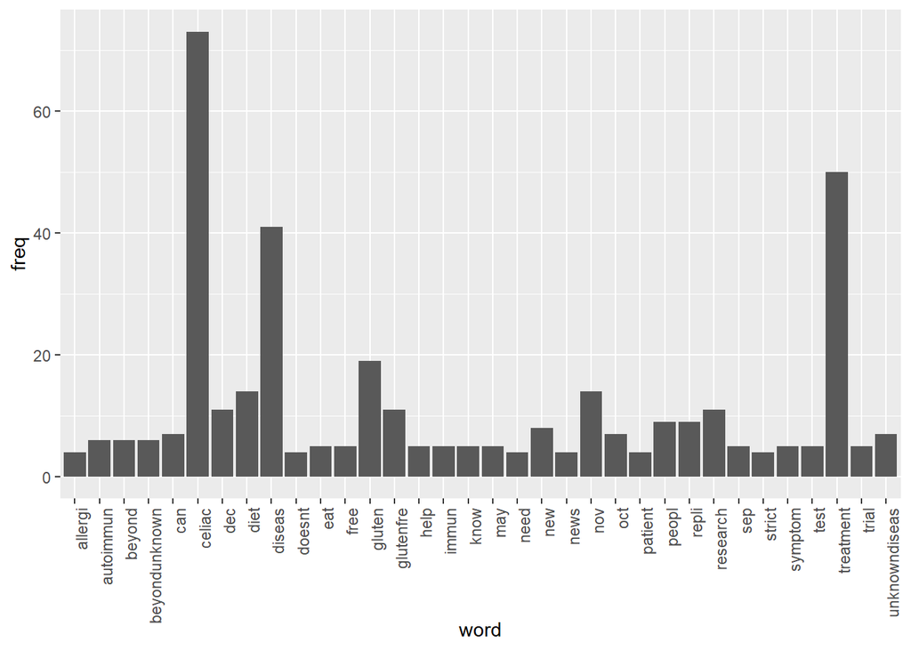

```r
wf <- data.frame(word=names(freq), freq=freq)
p <- ggplot(subset(wf, freq>3), aes(word, freq))
p <- p + geom_bar(stat= 'identity')
p <- p + theme(axis.text.x=element_text(angle=90, hjust=1))
p
```

## The next plot is for words with a minimum

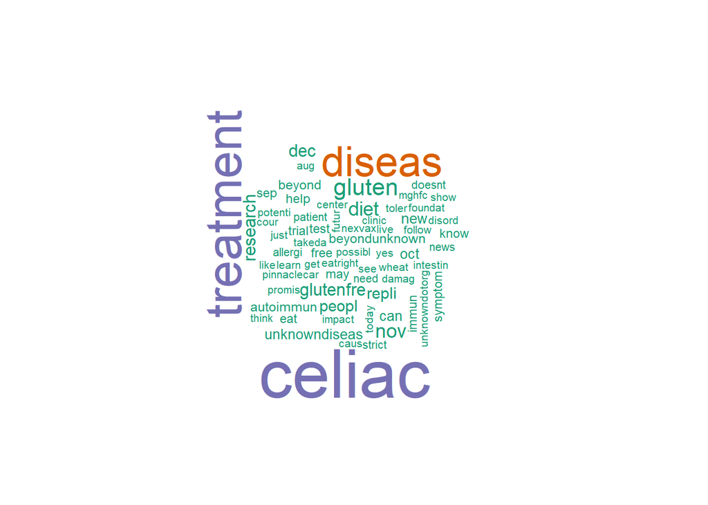

```r
wordcloud(names(freq), freq, min.freq=3,colors=brewer.pal(3,'Dark2'))
```

## This next plot is a word cloud based on the top 40 words in the corpus

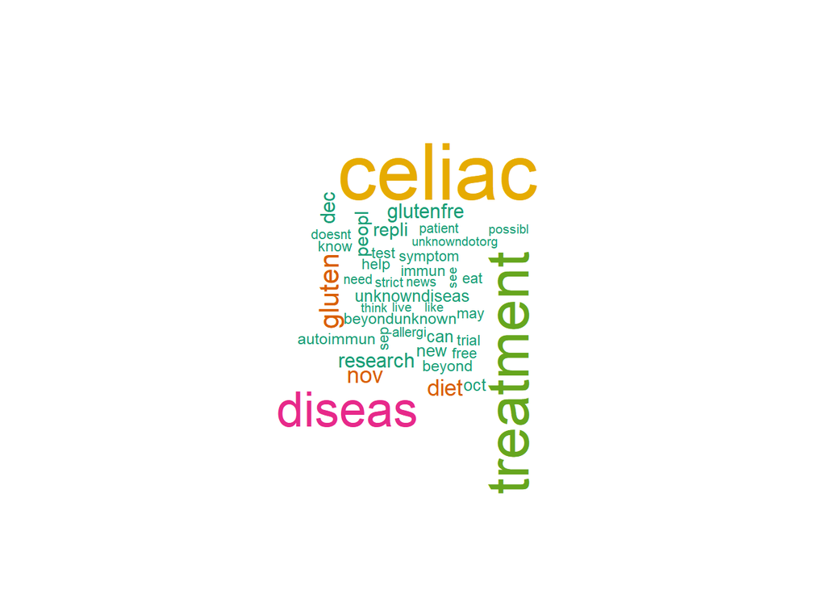

```r
wordcloud(names(freq), freq, max.words=40,colors=brewer.pal(6,'Dark2'))
```

## Now run the NLP word cloud and word frequencies for the other seven autoimmune diseases

```r
kidney <- Corpus(DirSource("Kidney1"))


kidney
```

```
## <<SimpleCorpus>>
## Metadata:  corpus specific: 1, document level (indexed): 0
## Content:  documents: 43
```

```r
kidney <- tm_map(kidney, removePunctuation)
kidney <- tm_map(kidney, removeNumbers)
kidney <- tm_map(kidney, tolower)
kidney <- tm_map(kidney, removeWords, stopwords("english"))
kidney <- tm_map(kidney, stripWhitespace)
kidney <- tm_map(kidney, stemDocument)
```

## Create the document term matrix (dtm) for this corpus

```r
dtmkidney <- DocumentTermMatrix(kidney)
dtmkidney
```

```
## <<DocumentTermMatrix (documents: 43, terms: 563)>>
## Non-/sparse entries: 874/23335
## Sparsity           : 96%
## Maximal term length: 43
## Weighting          : term frequency (tf)
```

## order the frequencies of each word and store the frequencies and ordered values

```r
freq <- colSums(as.matrix(dtmkidney))
```

# Replace the UNKNOWN with the disease name dn

```r
dn <- 'kidney'

unk <- grep('unknown', names(freq))
names(freq)[unk]
```

```
## [1] "unknown"               "unknowndiseas"         "unknowndiseasetreat"
## [4] "diseaseunknown"        "diabeticunknowndiseas" "unknowndiseaseri"
```

```r
names(freq)[unk[1]] <- dn
length(names(freq))
```

```
## [1] 563
```

```r
head(names(freq))
```

```
## [1] "cell"                   "center"
## [3] "httpstemmedicaindiacom" "india"
## [5] "intern"                 "medica"
```

```r
tail(names(freq))
```

```
## [1] "metformin"    "rclaurenefro" "reduc"        "rolando"
## [5] "roumi"        "sulfonylurea"
```

```r
grep('kidney',names(freq))
```

```
## [1] 33
```

## The dtmkidney colnames for ‘unknown’ has to be changed to dn

```r
colnames(dtmkidney)[unk[1]] <- dn
findAssocs(dtmkidney, dn, corlimit=0.4)
```

```
## $kidney
##     diseas transplant   diagnosi
##       0.46       0.43       0.43
```

```r
findAssocs(dtmkidney, "dialysi", corlimit=0.5)
```

```
## $dialysi
##   longterm transplant
##       0.69       0.54
```

```r
findAssocs(dtmkidney, "treatment", corlimit=0.5)
```

```
## $treatment
##       america auriniapharma       foundat        histor           iii
##          0.74          0.74          0.74          0.74          0.74
##      lupusorg      nephriti       potenti         share        thrill
##          0.74          0.74          0.74          0.74          0.74
##   voclosporin         lupus          news          read
##          0.74          0.60          0.57          0.54
```

## This next plot is a bar chart of the word frequencies, unknown is the disease.

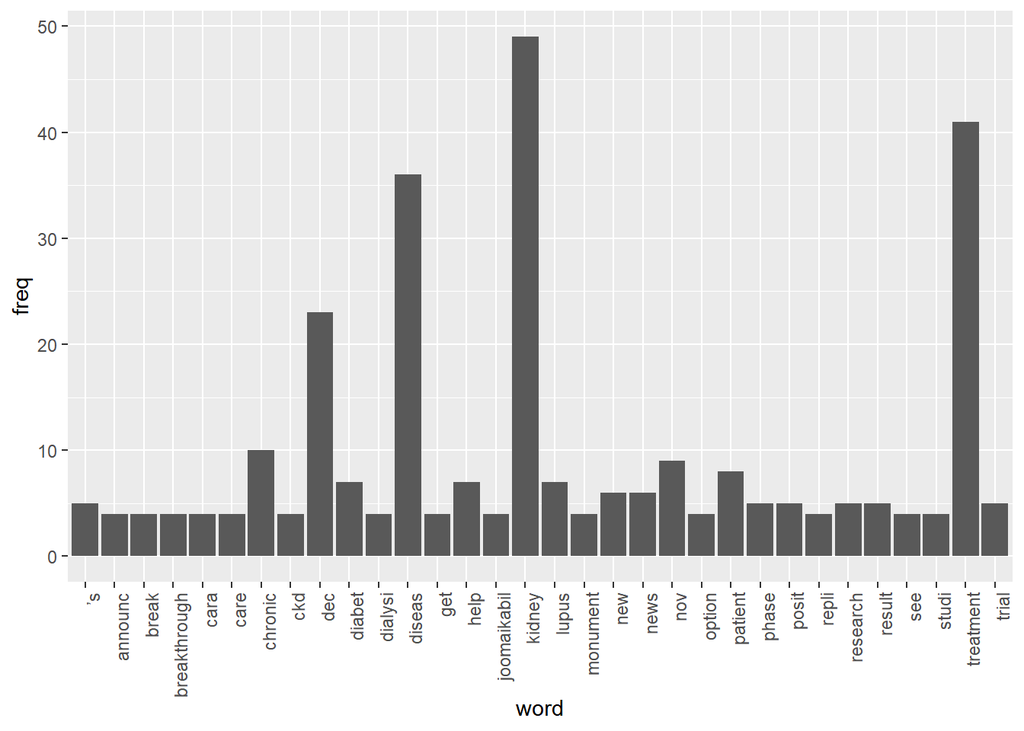

```r
wf <- data.frame(word=names(freq), freq=freq)
p <- ggplot(subset(wf, freq>3), aes(word, freq))
p <- p + geom_bar(stat= 'identity')
p <- p + theme(axis.text.x=element_text(angle=90, hjust=1))
p
```

## The next plot is for words with a minimum

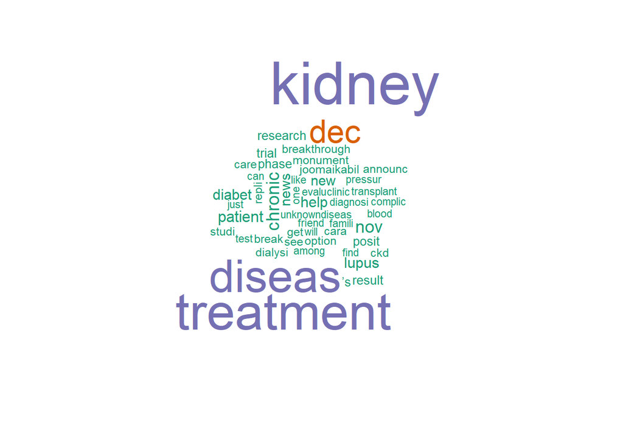

```r
wordcloud(names(freq), freq, min.freq=3,colors=brewer.pal(3,'Dark2'))
```

## This next plot is a word cloud based on the top 40 words in the corpus

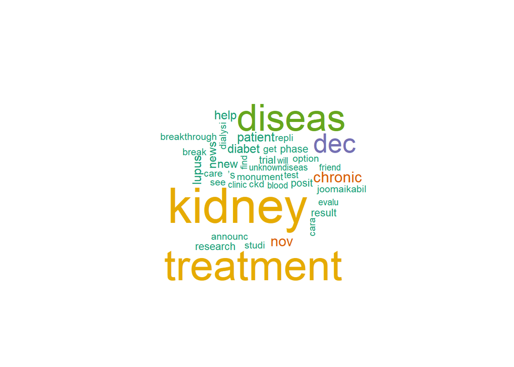

```r
wordcloud(names(freq), freq, max.words=40,colors=brewer.pal(6,'Dark2'))
```

```r
leukemia <- Corpus(DirSource("Leukemia1"))


leukemia
```

```
## <<SimpleCorpus>>
## Metadata:  corpus specific: 1, document level (indexed): 0
## Content:  documents: 119
```

```r
leukemia <- tm_map(leukemia, removePunctuation)
leukemia <- tm_map(leukemia, removeNumbers)
leukemia <- tm_map(leukemia, tolower)
leukemia <- tm_map(leukemia, removeWords, stopwords("english"))
leukemia <- tm_map(leukemia, stripWhitespace)
leukemia <- tm_map(leukemia, stemDocument)
```

## Create the document term matrix (dtm) for this corpus

```r
dtmleukemia <- DocumentTermMatrix(leukemia)
dtmleukemia
```

```
## <<DocumentTermMatrix (documents: 119, terms: 1305)>>
## Non-/sparse entries: 2671/152624
## Sparsity           : 98%
## Maximal term length: 74
## Weighting          : term frequency (tf)
```

## order the frequencies of each word and store the frequencies and ordered values

```r
freq <- colSums(as.matrix(dtmleukemia))
```

# Replace the UNKNOWN with the disease name dn

```r
dn <- 'leukemia'

unk <- grep('unknown', names(freq))
#names(freq)[unk]
```

```r
names(freq)[unk[1]] <- dn
length(names(freq))
```

```
## [1] 1305
```

```r
head(names(freq))
```

```
## [1] "attimpact" "attjob"    "back"      "blood"     "cousin’"   "donat"
```

```r
tail(names(freq))
```

```
## [1] "jeremycorbyn"                 "knew"
## [3] "rickyspur"                    "what"
## [5] "wrong"                        "httpinstagramcompblgwkmazzx…"
```

```r
FREQ <- data.frame(freq)
ord <- order(freq, decreasing=TRUE)
head(FREQ)
```

```
##           freq
## attimpact    1
## attjob       2
## back         3
## blood       22
## cousin’      1
## donat       10
```

```r
grep('leukemia',names(freq))
```

```
## [1]   11  103  591  713  814  824  973 1084 1172
```

## The dtmleukemia colnames for ‘unknown’ has to be changed to dn

```r
colnames(dtmleukemia)[unk[1]] <- dn
findAssocs(dtmleukemia, dn, corlimit=0.3)
```

```
## $leukemia
##        combin   leukemiabio     cytarabin         enzym       fmslike
##          0.47          0.47          0.45          0.45          0.45
##        implic        involv           key         kinas       metabol
##          0.45          0.45          0.45          0.45          0.45
##         modul     nucleotid       tyrosin     tyrosine…          acut
##          0.45          0.45          0.45          0.45          0.38
##           flt    venetoclax       pediatr         might mdandersonnew
##          0.38          0.38          0.35          0.31          0.31
```

```r
findAssocs(dtmleukemia, "enzym", corlimit=0.5)
```

```
## $enzym
##   cytarabin     fmslike      implic      involv         key       kinas
##        1.00        1.00        1.00        1.00        1.00        1.00
##     metabol       modul   nucleotid     tyrosin   tyrosine…     pediatr
##        1.00        1.00        1.00        1.00        1.00        0.82
##      combin leukemiabio       might         flt
##        0.70        0.70        0.70        0.57
```

```r
findAssocs(dtmleukemia, "discov", corlimit=0.857)
```

```
## $discov
##                                                          bonemarrow
##                                                                1.00
## httpsmanuscripteditcomscholarhangoutproteincanhelptreatmentleukemia
##                                                                1.00
##                                                      manuscriptedit
##                                                                1.00
##                                                   manuscripteditcom
##                                                                1.00
##                                                                mllt
##                                                                1.00
##                                                              produc
##                                                                1.00
##                                                             stemcel
##                                                                1.00
##                                                             protein
##                                                                0.89
```

## This next plot is a bar chart of the word frequencies, unknown is the disease.

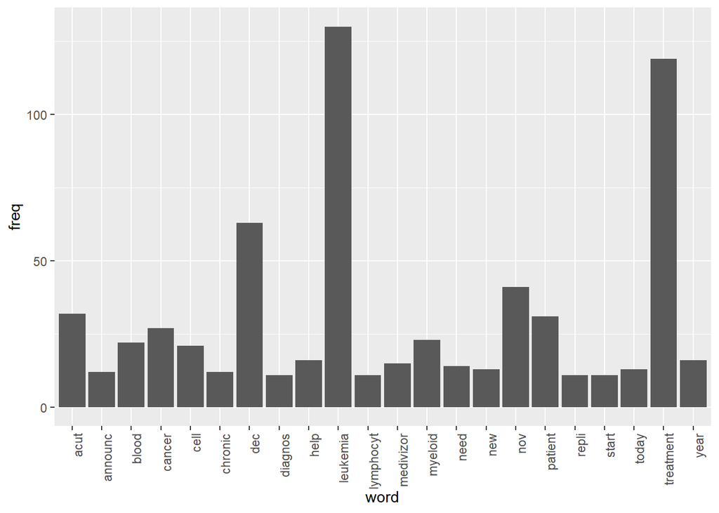

```r
wf <- data.frame(word=names(freq), freq=freq)
p <- ggplot(subset(wf, freq>10), aes(word, freq))
p <- p + geom_bar(stat= 'identity')
p <- p + theme(axis.text.x=element_text(angle=90, hjust=1))
p
```

## The next plot is for words with a minimum

## frequency of 10 in the corpus of tweets.

[figure not shown]

```r
wordcloud(names(freq), freq, min.freq=10,colors=brewer.pal(3,'Dark2'))
```

## This next plot is a word cloud based on the top 40 words in the corpus

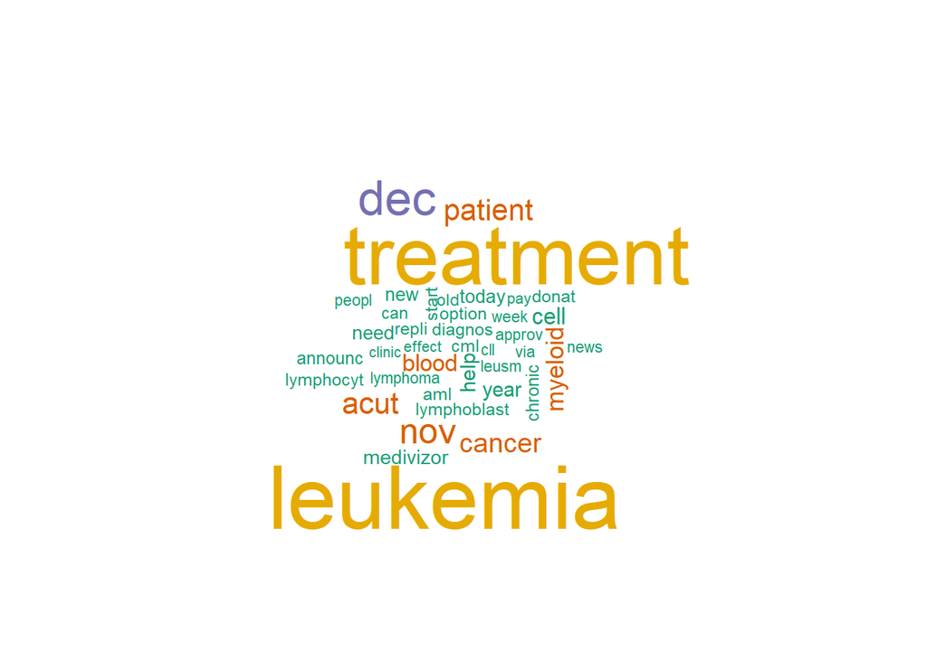

```r
wordcloud(names(freq), freq, max.words=40,colors=brewer.pal(6,'Dark2'))
```

```r
ms <- Corpus(DirSource("MS1"))


ms
```

```
## <<SimpleCorpus>>
## Metadata:  corpus specific: 1, document level (indexed): 0
## Content:  documents: 119
```

```r
ms <- tm_map(ms, removePunctuation)
ms <- tm_map(ms, removeNumbers)
ms <- tm_map(ms, tolower)
ms <- tm_map(ms, removeWords, stopwords("english"))
ms <- tm_map(ms, stripWhitespace)
ms <- tm_map(ms, stemDocument)
```

## Create the document term matrix (dtm) for this corpus

```r
dtmms <- DocumentTermMatrix(ms)
dtmms
```

```
## <<DocumentTermMatrix (documents: 119, terms: 1233)>>
## Non-/sparse entries: 2399/144328
## Sparsity           : 98%
## Maximal term length: 100
## Weighting          : term frequency (tf)
```

## order the frequencies of each word and store the frequencies and ordered values

```r
freq <- colSums(as.matrix(dtmms))
```

# Replace the UNKNOWN with the disease name dn

```r
dn <- 'ms'

unk <- grep('unknown', names(freq))
names(freq)[unk]
```

```
##  [1] "actriunknown"
##  [2] "unknown"
##  [3] "httpsjiyoindiacomspecialityunknownunknowntreat"
##  [4] "unknownplatforma"
##  [5] "unknownunknown"
##  [6] "httpsnewcastleeduaunewsroomfeaturednewsfundingsignalsnewhopeforunknownunknowntreat"
##  [7] "unknownrel"
##  [8] "httpsescalatesciencescomposttreatingunknownunknownwiththehelpofthegutmicrobiom"
##  [9] "ectriunknown"
## [10] "spunknown"
## [11] "surreyunknown"
## [12] "unknownlif"
## [13] "unknowntreat"
## [14] "progressiveunknown"
## [15] "myunknownteam"
## [16] "unknownbio"
## [17] "pwunknown"
## [18] "symptounknown"
## [19] "httpsucsdimwordpresscommtcacquiredfactorviiideficiencyduetoalemtuzumabtreatmentforunknownunknown"
## [20] "livewiseunknown"
## [21] "livewiseunknownorg"
## [22] "moreunknown"
## [23] "theunknownguild"
## [24] "stopunknown"
## [25] "unknownrd"
## [26] "hesunknownc…"
## [27] "unknownc"
```

```r
names(freq)[unk[2]] <- dn
length(names(freq))
```

```
## [1] 1233
```

```r
head(names(freq))
```

```
## [1] "actriunknown"  "america"       "attend"        "committe"
## [5] "dukeshinohara" "elizabeth"
```

```r
tail(names(freq))
```

```
## [1] "govern"     "maddow"     "maddowblog" "undergo"    "usda"
## [6] "week"
```

```r
FREQ <- data.frame(freq)
ord <- order(freq, decreasing=TRUE)
head(FREQ)
```

```
##               freq
## actriunknown     1
## america          1
## attend           2
## committe         2
## dukeshinohara    1
## elizabeth        2
```

```r
grep('ms',names(freq))
```

```
## [1]   34  121  172  566  765  932 1206
```

## The dtmms colnames for ‘unknown’ has to be changed to dn

```r
#colnames(dtmms)[unk[2]] <- dn
findAssocs(dtmms, 'sclerosi', corlimit=0.3)
```

```
## $sclerosi
## multipl   india
##    0.86    0.32
```

```r
findAssocs(dtmms, "multipl", corlimit=0.3)
```

```
## $multipl
##        sclerosi    fabulousjess fabulousjessica              m…
##            0.86            0.47            0.47            0.47
##         neuriti            nurs           optic         symptom
##            0.47            0.47            0.47            0.44
##            sign
##            0.39
```

```r
findAssocs(dtmms, "treatment", corlimit=0.4)
```

```
## $treatment
##       general        genphi           gpl           jun    laboratori
##           0.4           0.4           0.4           0.4           0.4
## nanotechnolog      nanowerk     nanowerka        physic
##           0.4           0.4           0.4           0.4
```

## This next plot is a bar chart of the word frequencies, unknown is the disease.

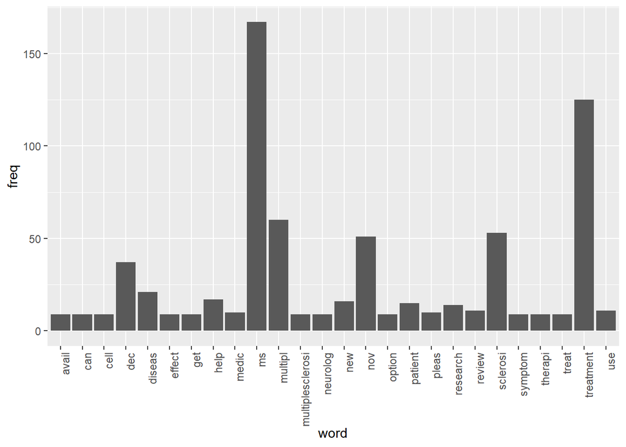

```r
wf <- data.frame(word=names(freq), freq=freq)
p <- ggplot(subset(wf, freq>8), aes(word, freq))
p <- p + geom_bar(stat= 'identity')
p <- p + theme(axis.text.x=element_text(angle=90, hjust=1))
p
```

## The next plot is for words with a minimum

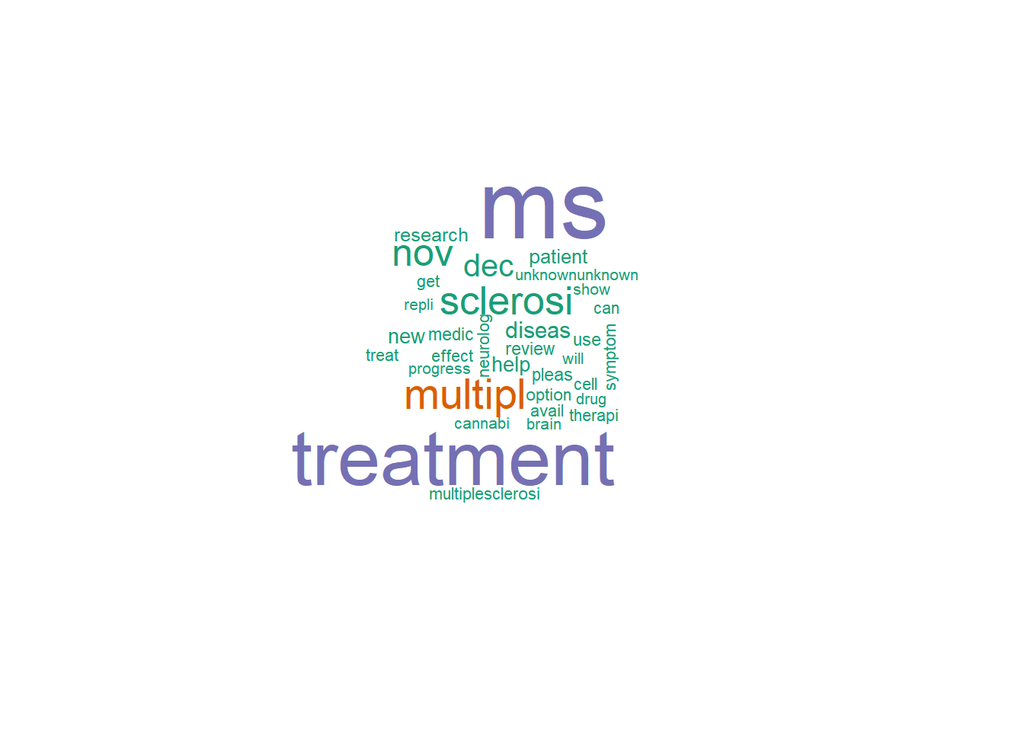

```r
wordcloud(names(freq), freq, min.freq=8,colors=brewer.pal(3,'Dark2'))
```

## This next plot is a word cloud based on the top 40 words in the corpus

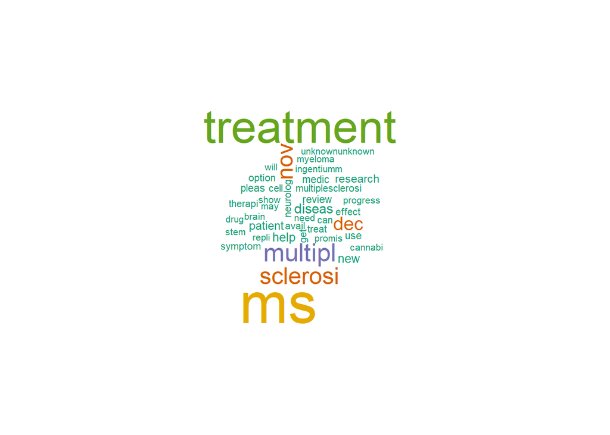

```r
wordcloud(names(freq), freq, max.words=40,colors=brewer.pal(6,'Dark2'))
```

```r
fibromyalgia <- Corpus(DirSource("Fibromyalgia1"))


fibromyalgia
```

```
## <<SimpleCorpus>>
## Metadata:  corpus specific: 1, document level (indexed): 0
## Content:  documents: 99
```

```r
fibromyalgia <- tm_map(fibromyalgia, removePunctuation)
fibromyalgia <- tm_map(fibromyalgia, removeNumbers)
fibromyalgia <- tm_map(fibromyalgia, tolower)
fibromyalgia <- tm_map(fibromyalgia, removeWords, stopwords("english"))
fibromyalgia <- tm_map(fibromyalgia, stripWhitespace)
fibromyalgia <- tm_map(fibromyalgia, stemDocument)
```

## Create the document term matrix (dtm) for this corpus

```r
dtmfibromyalgia <- DocumentTermMatrix(fibromyalgia)
dtmfibromyalgia
```

```
## <<DocumentTermMatrix (documents: 99, terms: 1296)>>
## Non-/sparse entries: 2656/125648
## Sparsity           : 98%
## Maximal term length: 106
## Weighting          : term frequency (tf)
```

## order the frequencies of each word and store the frequencies and ordered values

```r
freq <- colSums(as.matrix(dtmfibromyalgia))
```

# Replace the UNKNOWN with the disease name dn

```r
dn <- 'fibromyalgia'

unk <- grep('unknown', names(freq))
names(freq)[unk]
```

```
##  [1] "unknown"
##  [2] "httpssoisunknownrealcomicantvouchforaquickfixunknowntreatmentbutaprolongedpathimin"
##  [3] "soisunknownrealcom"
##  [4] "unknown…"
##  [5] "httpsonlinemedicalcardcomblogmarijuanaforunknown"
##  [6] "unknown”"
##  [7] "unknownwomencom"
##  [8] "unknownsol"
##  [9] "“unknown"
## [10] "httpbackpainblogukcomantidepressantsasatreatmentforunknown"
## [11] "unknownrel"
## [12] "nlounknown"
## [13] "unknownnewlifeoutlookcom"
## [14] "httplivingwithunknownnetinflamedribcartilagesymptomsandunknowntreat"
## [15] "httpnationalpainreportcomcananexistingvaccinehelptreatunknownhtml"
```

```r
names(freq)[unk[1]] <- dn
length(names(freq))
```

```
## [1] 1296
```

```r
head(names(freq))
```

```
## [1] "aai"           "achiev"        "call"          "cci"
## [5] "cfs"           "chronicfatigu"
```

```r
tail(names(freq))
```

```
## [1] "brandonpetersmd" "breath"          "causat"          "peter"
## [5] "sleepapnea"      "worsen"
```

```r
FREQ <- data.frame(freq)
ord <- order(freq, decreasing=TRUE)
head(FREQ)
```

```
##               freq
## aai              1
## achiev           1
## call             1
## cci              1
## cfs              2
## chronicfatigu    1
```

```r
grep('fibromyalgia',names(freq))
```

```
## [1] 46
```

## The dtmfibromyalgia colnames for ‘unknown’ has to be changed to dn

```r
colnames(dtmfibromyalgia)[unk[1]] <- dn
findAssocs(dtmfibromyalgia, dn, corlimit=0.3)
```

```
## $fibromyalgia
##                treatment                   attent                    bring
##                     0.43                     0.40                     0.40
##                   credit               deafbutcut                     ladi
##                     0.40                     0.40                     0.40
##                   ramona                  rusilko                     talk
##                     0.40                     0.40                     0.40
##          unknownwomencom                     gaga                   depend
##                     0.40                     0.37                     0.31
##                      nlo               nlounknown                 question
##                     0.31                     0.31                     0.31
##                     rein unknownnewlifeoutlookcom                  without
##                     0.31                     0.31                     0.31
##                      ask                   fix…’v                    guess
##                     0.30                     0.30                     0.30
##                     love               obviously…                     path
##                     0.30                     0.30                     0.30
##                  prolong                    quick                seventeen
##                     0.30                     0.30                     0.30
##       soisunknownrealcom                  sometim               treatment…
##                     0.30                     0.30                     0.30
##                    vouch                       ’d                    reduc
##                     0.30                     0.30                     0.30
##                    tackl                   target
##                     0.30                     0.30
```

```r
findAssocs(dtmfibromyalgia, "pain", corlimit=0.6)
```

```
## $pain
##        across      advocaci       announc      collabor       compris
##          0.62          0.62          0.62          0.62          0.62
##        leader        method      pinpoint     prnewswir prnewswirecom
##          0.62          0.62          0.62          0.62          0.62
##        public          titl        assess
##          0.62          0.62          0.60
```

```r
findAssocs(dtmfibromyalgia, "treatment", corlimit=0.35)
```

```
## $treatment
## fibromyalgia          via       option
##         0.43         0.42         0.37
```

## This next plot is a bar chart of the word frequencies, unknown is the disease.

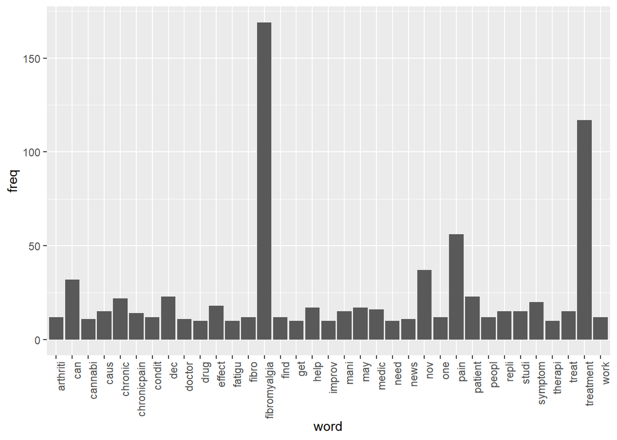

```r
wf <- data.frame(word=names(freq), freq=freq)
p <- ggplot(subset(wf, freq>9), aes(word, freq))
p <- p + geom_bar(stat= 'identity')
p <- p + theme(axis.text.x=element_text(angle=90, hjust=1))
p
```

## The next plot is for words with a minimum

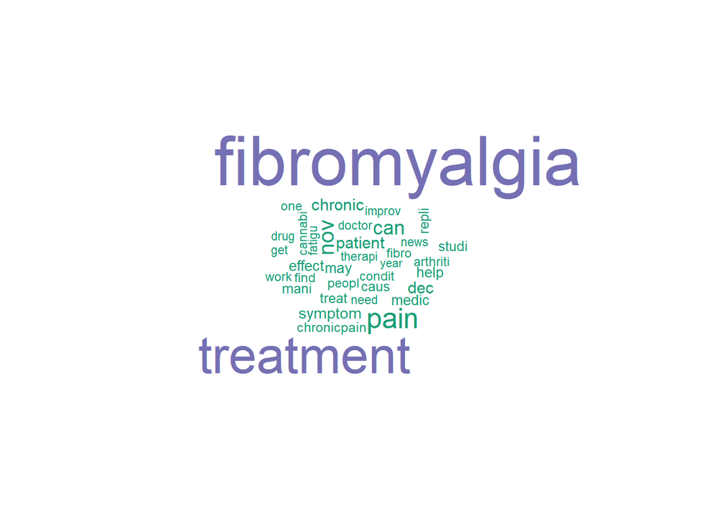

```r
wordcloud(names(freq), freq, min.freq=9,colors=brewer.pal(3,'Dark2'))
```

## This next plot is a word cloud based on the top 40 words in the corpus

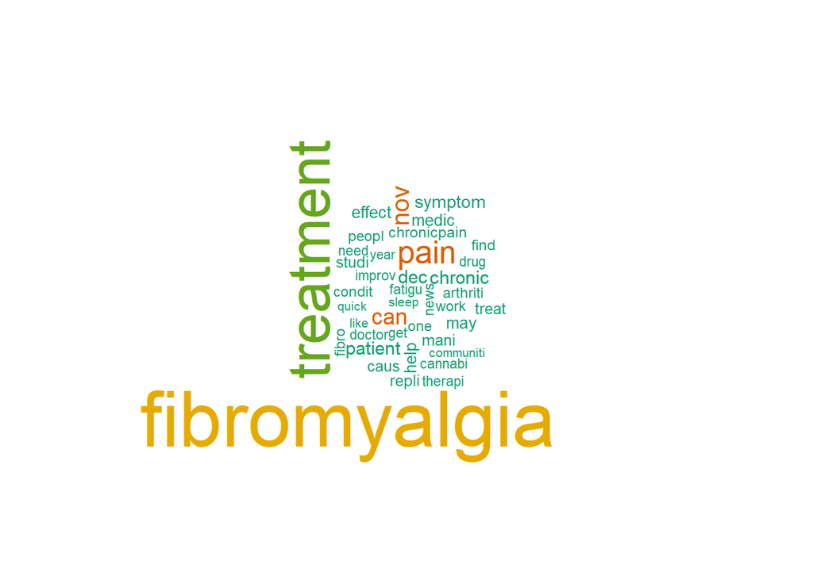

```r
wordcloud(names(freq), freq, max.words=40,colors=brewer.pal(6,'Dark2'))
```

```r
hashimoto <- Corpus(DirSource("Hashimoto1"))


hashimoto
```

```
## <<SimpleCorpus>>
## Metadata:  corpus specific: 1, document level (indexed): 0
## Content:  documents: 30
```

```r
hashimoto <- tm_map(hashimoto, removePunctuation)
hashimoto <- tm_map(hashimoto, removeNumbers)
hashimoto <- tm_map(hashimoto, tolower)
hashimoto <- tm_map(hashimoto, removeWords, stopwords("english"))
hashimoto <- tm_map(hashimoto, stripWhitespace)
hashimoto <- tm_map(hashimoto, stemDocument)
```

## Create the document term matrix (dtm) for this corpus

```r
dtmhashimoto <- DocumentTermMatrix(hashimoto)
dtmhashimoto
```

```
## <<DocumentTermMatrix (documents: 30, terms: 427)>>
## Non-/sparse entries: 647/12163
## Sparsity           : 95%
## Maximal term length: 28
## Weighting          : term frequency (tf)
```

## order the frequencies of each word and store the frequencies and ordered values

```r
freq <- colSums(as.matrix(dtmhashimoto))
```

# Replace the UNKNOWN with the disease name dn

```r
dn <- 'hashimoto'

unk <- grep('unknown', names(freq))
names(freq)[unk]
```

```
## [1] "unknownunknown"              "unknownunknownsthyroid"
## [3] "httpdrradhikascomunknownsdi" "unknownunknown’"
## [5] "unknown"                     "runknownunknown"
## [7] "unknown’"
```

```r
names(freq)[unk[1]] <- dn
length(names(freq))
```

```
## [1] 427
```

```r
head(names(freq))
```

```
## [1] "diseas" "effect" "hormon" "mayo"   "nov"    "puro"
```

```r
tail(names(freq))
```

```
## [1] "tissu"    "turner’"  "uneth"    "unknown’" "without"  "’s"
```

```r
FREQ <- data.frame(freq)
ord <- order(freq, decreasing=TRUE)
head(FREQ)
```

```
##        freq
## diseas   17
## effect    3
## hormon    6
## mayo      1
## nov       4
## puro      1
```

```r
grep('hashimoto',names(freq))
```

```
## [1] 13
```

## The dtmhashimoto colnames for ‘unknown’ has to be changed to dn

```r
colnames(dtmhashimoto)[unk[1]] <- dn
findAssocs(dtmhashimoto, dn, corlimit=0.4)
```

```
## $hashimoto
##                  avoid               children                correct
##                   0.47                   0.47                   0.47
##     diseasesinchildren                essenti             rarediseas
##                   0.47                   0.47                   0.47
## unknownunknownsthyroid              webmedium
##                   0.47                   0.47
```

```r
findAssocs(dtmhashimoto, "treatment", corlimit=0.4)
```

```
## $treatment
##                  acupressur                  acupunctur
##                        0.78                        0.78
##                    allopath                     convent
##                        0.78                        0.78
##                   drradhika                   homeopath
##                        0.78                        0.78
## httpdrradhikascomunknownsdi               psychotherapi
##                        0.78                        0.78
##                     radhika             unknownunknown’
##                        0.78                        0.65
##                      diseas                         nov
##                        0.59                        0.48
```

```r
findAssocs(dtmhashimoto, "thyroid", corlimit=0.4)
```

```
## $thyroid
##         condit doctorflamecom          flame  flameinstitut          gland
##           0.69           0.69           0.69           0.69           0.69
##           help       institut          iodin         method           stop
##           0.69           0.69           0.69           0.69           0.69
##         textur           type              …           best         system
##           0.69           0.69           0.69           0.68           0.58
##           caus            can    hypothyroid      autoimmun
##           0.52           0.51           0.47           0.47
```

## This next plot is a bar chart of the word frequencies, unknown is the disease.

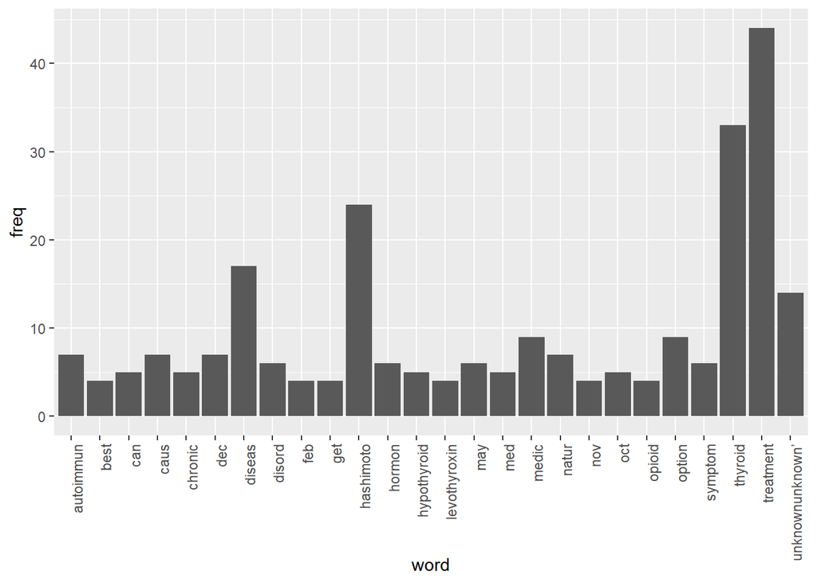

```r
wf <- data.frame(word=names(freq), freq=freq)
p <- ggplot(subset(wf, freq>3), aes(word, freq))
p <- p + geom_bar(stat= 'identity')
p <- p + theme(axis.text.x=element_text(angle=90, hjust=1))
p
```

## The next plot is for words with a minimum

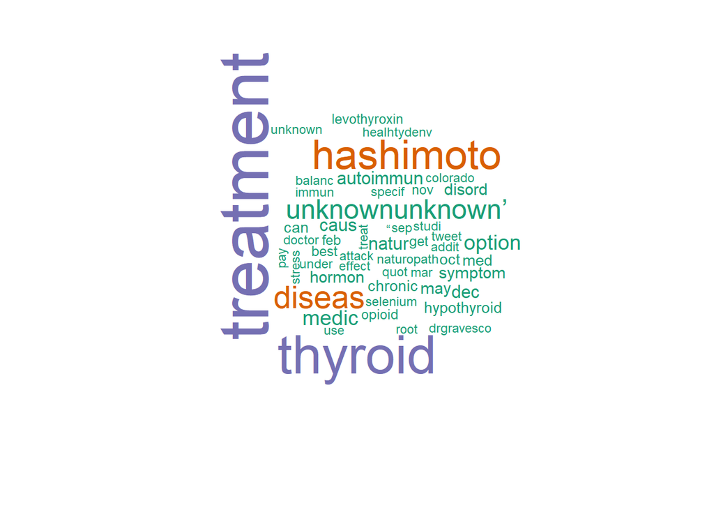

```r
wordcloud(names(freq), freq, min.freq=3,colors=brewer.pal(3,'Dark2'))
```

## This next plot is a word cloud based on the top 40 words in the corpus

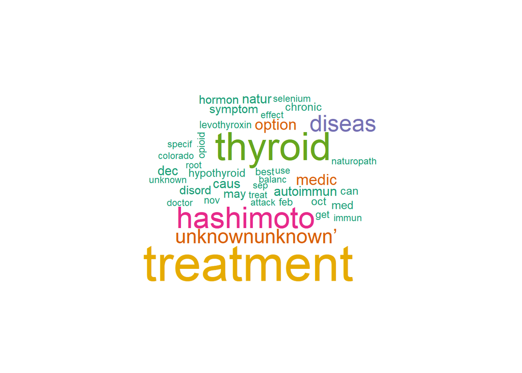

```r
wordcloud(names(freq), freq, max.words=40,colors=brewer.pal(6,'Dark2'))
```

```r
ra <- Corpus(DirSource("RA1"))


ra
```

```
## <<SimpleCorpus>>
## Metadata:  corpus specific: 1, document level (indexed): 0
## Content:  documents: 28
```

```r
ra <- tm_map(ra, removePunctuation)
ra <- tm_map(ra, removeNumbers)
ra <- tm_map(ra, tolower)
ra <- tm_map(ra, removeWords, stopwords("english"))
ra <- tm_map(ra, stripWhitespace)
ra <- tm_map(ra, stemDocument)
```

## Create the document term matrix (dtm) for this corpus

```r
dtmra <- DocumentTermMatrix(ra)
dtmra
```

```
## <<DocumentTermMatrix (documents: 28, terms: 390)>>
## Non-/sparse entries: 551/10369
## Sparsity           : 95%
## Maximal term length: 171
## Weighting          : term frequency (tf)
```

## order the frequencies of each word and store the frequencies and ordered values

```r
freq <- colSums(as.matrix(dtmra))
```

# Replace the UNKNOWN with the disease name dn

```r
dn <- 'ra'

unk <- grep('unknown', names(freq))
names(freq)[unk]
```

```
##  [1] "httpsunknownresearchcaourteamresea"
##  [2] "unknown"
##  [3] "unknownarc"
##  [4] "unknownresearchca"
##  [5] "tremeunknown"
##  [6] "unknownbio"
##  [7] "unknownat"
##  [8] "unknownunknown"
##  [9] "unknowninterstiti"
## [10] "unknownnow"
## [11] "httpsdocwirenewscomdocwirepickunknownatologypicksmostunknownunknownpatientsaredissatisfiedwithtreatmentutmsourcetwittershareutmmediumsocialmediautmcampaignsocialmediatrack"
## [12] "globalunknownato"
## [13] "unknownatolog"
## [14] "ourunknown"
## [15] "unknownathoidunknown"
## [16] "unknownadvisor"
## [17] "httpgsehealthcomunknownunknowntreatmentguidelin"
## [18] "unknownawarenessmonth"
## [19] "scotunknown"
## [20] "cureunknown"
## [21] "unknowninform"
## [22] "unknownatologist"
```

```r
names(freq)[unk[2]] <- dn
length(names(freq))
```

```
## [1] 390
```

```r
head(names(freq))
```

```
## [1] "allianc"  "award"    "can"      "canada"   "career"   "determin"
```

```r
tail(names(freq))
```

```
## [1] "homeopathyinfo"  "httpbitlygyiion" "httpbitlykpfc"   "review"
## [5] "safehomeopathi"  "watch"
```

```r
FREQ <- data.frame(freq)
ord <- order(freq, decreasing=TRUE)
head(FREQ)
```

```
##          freq
## allianc     1
## award       1
## can         2
## canada      1
## career      1
## determin    1
```

```r
grep('ra',names(freq))
```

```
## [1]  23  95 214 230 287 345 353 364 382
```

## The dtmra colnames for ‘unknown’ has to be changed to dn

```r
colnames(dtmra)[unk[2]] <- dn
findAssocs(dtmra, dn, corlimit=0.4)
```

```
## $ra
##          auto      ayurveda        detail        especi          high
##          0.60          0.60          0.60          0.60          0.60
## httpbitlytliv       indheal         treat     unknownat         immun
##          0.60          0.60          0.60          0.60          0.57
##     treatment         earli           oct          type
##          0.46          0.44          0.43          0.43
```

```r
findAssocs(dtmra, "treatment", corlimit=0.4)
```

```
## $treatment
##   ra
## 0.46
```

```r
findAssocs(dtmra, "pain", corlimit=0.3)
```

```
## $pain
##      andersen          bone        cancer    creakychat        intens
##          0.95          0.95          0.95          0.95          0.95
##          knew          lene moderatesever         peopl           saw
##          0.95          0.95          0.95          0.95          0.95
##           say       similar         taken theseatedview        urgent
##          0.95          0.95          0.95          0.95          0.95
##          wish           yet       serious           can          need
##          0.95          0.95          0.89          0.65          0.65
##       prevent           jun        effect
##          0.65          0.51          0.43
```

## This next plot is a bar chart of the word frequencies, unknown is the disease.

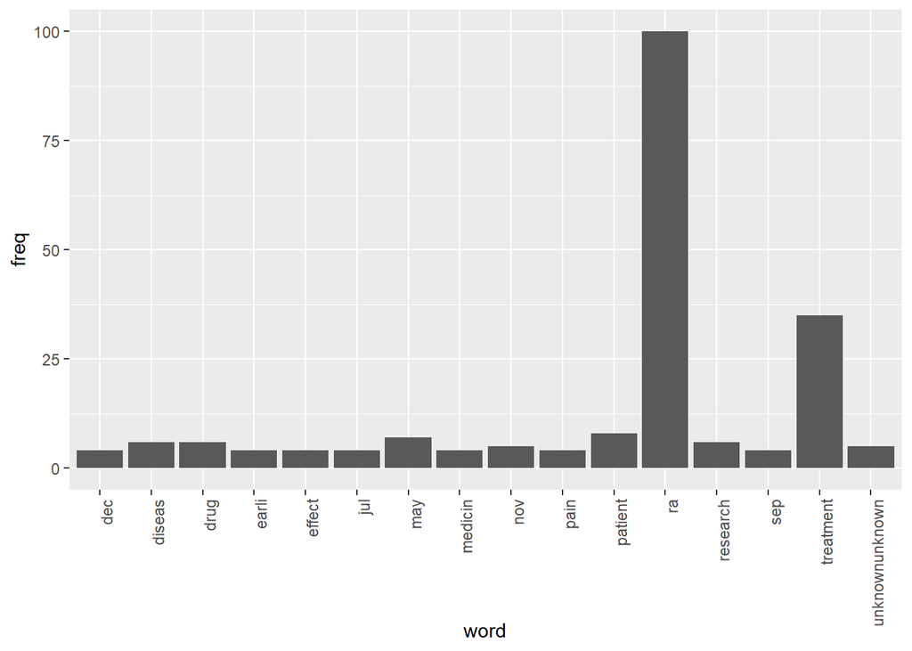

```r
wf <- data.frame(word=names(freq), freq=freq)
p <- ggplot(subset(wf, freq>3), aes(word, freq))
p <- p + geom_bar(stat= 'identity')
p <- p + theme(axis.text.x=element_text(angle=90, hjust=1))
p
```

## The next plot is for words with a minimum

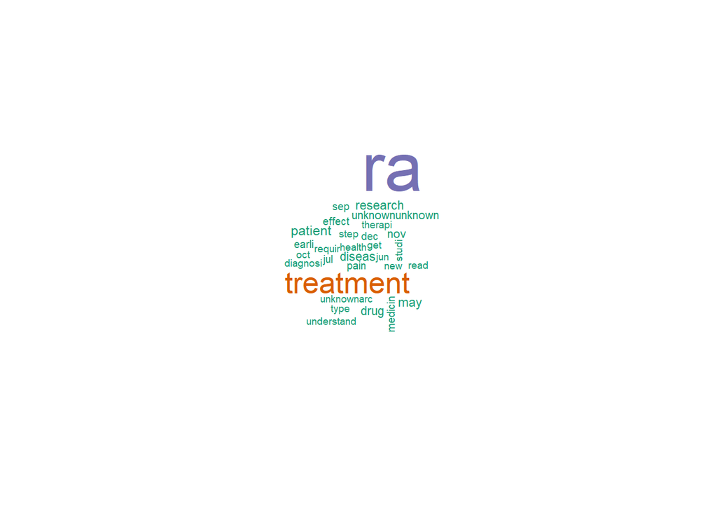

```r
wordcloud(names(freq), freq, min.freq=3,colors=brewer.pal(3,'Dark2'))
```

## This next plot is a word cloud based on the top 40 words in the corpus

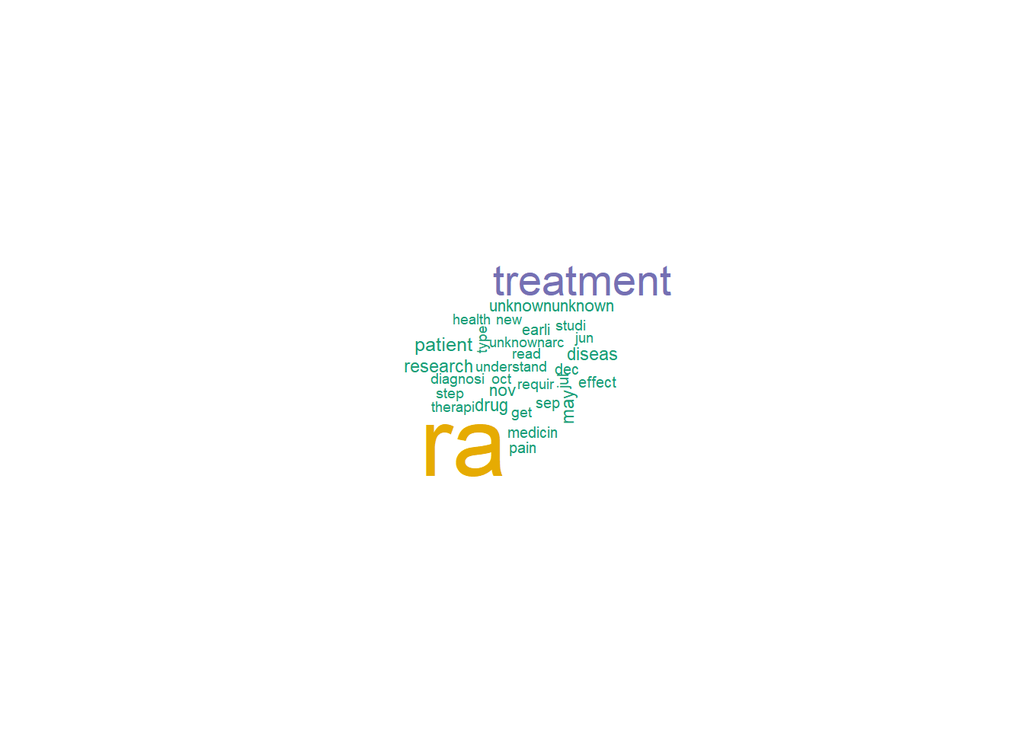

```r
wordcloud(names(freq), freq, max.words=40,colors=brewer.pal(6,'Dark2'))
```

```r
chron <- Corpus(DirSource("Chron1"))


chron
```

```
## <<SimpleCorpus>>
## Metadata:  corpus specific: 1, document level (indexed): 0
## Content:  documents: 19
```

```r
chron <- tm_map(chron, removePunctuation)
chron <- tm_map(chron, removeNumbers)
chron <- tm_map(chron, tolower)
chron <- tm_map(chron, removeWords, stopwords("english"))
chron <- tm_map(chron, stripWhitespace)
chron <- tm_map(chron, stemDocument)
```

## Create the document term matrix (dtm) for this corpus

```r
dtmchron <- DocumentTermMatrix(chron)
dtmchron
```

```
## <<DocumentTermMatrix (documents: 19, terms: 274)>>
## Non-/sparse entries: 360/4846
## Sparsity           : 93%
## Maximal term length: 26
## Weighting          : term frequency (tf)
```

## order the frequencies of each word and store the frequencies and ordered values

```r
freq <- colSums(as.matrix(dtmchron))
```

# Replace the UNKNOWN with the disease name dn

```r
FREQ <- as.data.frame(freq)
```

```r
dn <- 'chron'

unk <- grep('unknown', names(freq))
names(freq)[unk]
```

```
## [1] "unknown"
```

```r
names(freq)[unk[1]] <- dn
length(names(freq))
```

```
## [1] 274
```

```r
head(names(freq))
```

```
## [1] "back"    "calpico" "car"     "come"    "day"     "decid"
```

```r
tail(names(freq))
```

```
## [1] "drip"            "hook"            "httpyfrogcomfpj" "infleximab"
## [5] "nivik"           "roger"
```

```r
gr <- grep('chron',names(freq))
names(freq)[gr]
```

```
## [1] "chron"          "chron"          "disorderschron"
```

## The dtmchron colnames for ‘unknown’ has to be changed to dn

```r
colnames(dtmchron)[unk[1]] <- dn
findAssocs(dtmchron, dn, corlimit=0.3)
```

```
## $chron
##   back    now    jun hospit    arm daniel
##   0.33   0.33   0.33   0.33   0.33   0.33
```

```r
findAssocs(dtmchron, "treatment", corlimit=0.5)
```

```
## $treatment
##              anim            effect    everydayhealth everydayhealthcom
##              0.63              0.63              0.63              0.63
##               gut   gutmicrobiotaww           haven’t          helminth
##              0.63              0.63              0.63              0.63
##  httpowlyxgxvbqxo             human            involv         jenlaskey
##              0.63              0.63              0.63              0.63
##        microbiota           parasit            promis            proven
##              0.63              0.63              0.63              0.63
##              safe             studi           swallow           therapi
##              0.63              0.63              0.63              0.63
##              worm               yet
##              0.63              0.63
```

```r
findAssocs(dtmchron, "diseas", corlimit=0.5)
```

```
## $diseas
##         crohn       ailment          also         anoth        assist
##          0.71          0.53          0.53          0.53          0.53
##        associ         avail       bearabl        better          bind
##          0.53          0.53          0.53          0.53          0.53
##           can         chase       depress           eas          goos
##          0.53          0.53          0.53          0.53          0.53
##           ibd          issu         keith      kpascuch        kratom
##          0.53          0.53          0.53          0.53          0.53
##         legal          live       mention        normal           one
##          0.53          0.53          0.53          0.53          0.53
##        person         phila         point       problem      properti
##          0.53          0.53          0.53          0.53          0.53
##          quot         regul        remain        resolv         still
##          0.53          0.53          0.53          0.53          0.53
## thekratomassn         toler         tweet          well       barreto
##          0.53          0.53          0.53          0.53          0.53
##        common  httpbitlyeuq ketelslichtig     kklichtig         ulcer
##          0.53          0.53          0.53          0.53          0.53
##           jul
##          0.52
```

## This next plot is a bar chart of the word frequencies, unknown is the disease.

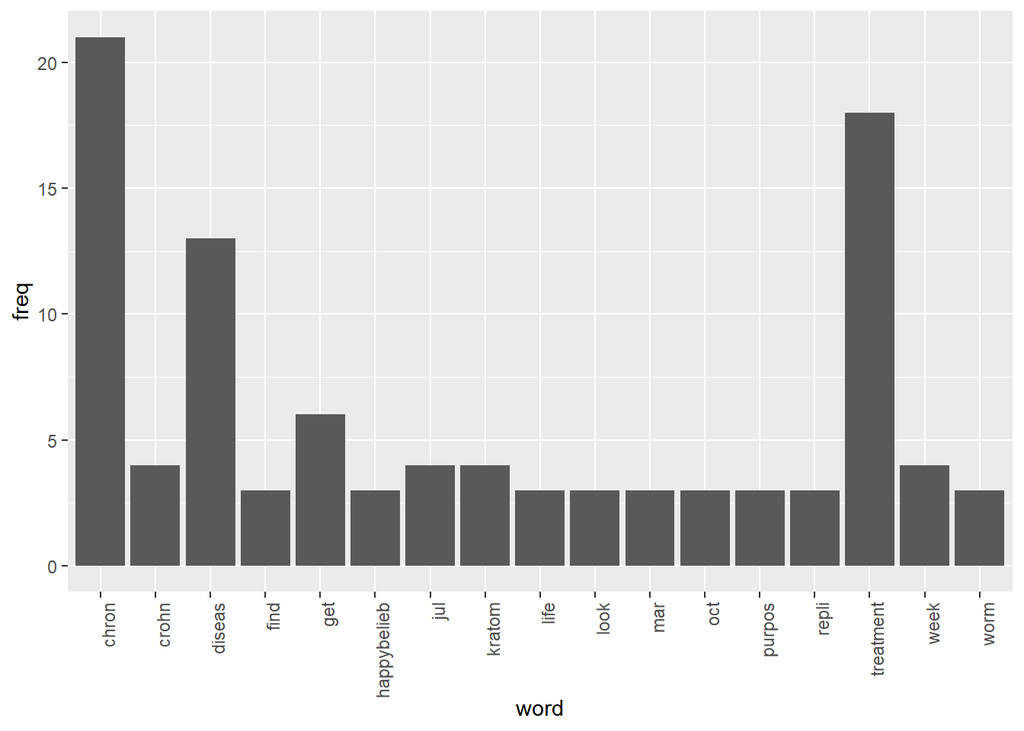

```r
wf <- data.frame(word=names(freq), freq=freq)
p <- ggplot(subset(wf, freq>2), aes(word, freq))
p <- p + geom_bar(stat= 'identity')
p <- p + theme(axis.text.x=element_text(angle=90, hjust=1))
p
```

## The next plot is for words with a minimum

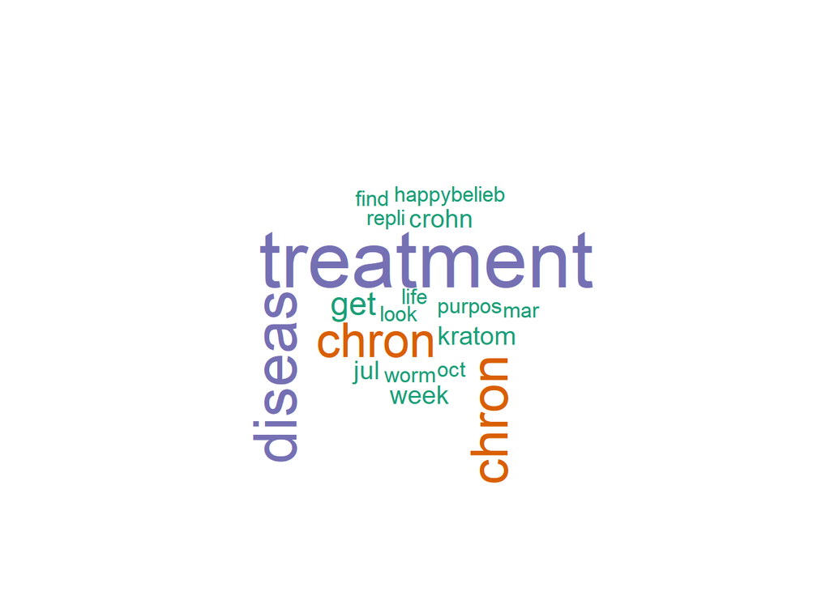

```r
wordcloud(names(freq), freq, min.freq=3,colors=brewer.pal(3,'Dark2'))
```

## This next plot is a word cloud based on the top 40 words in the corpus

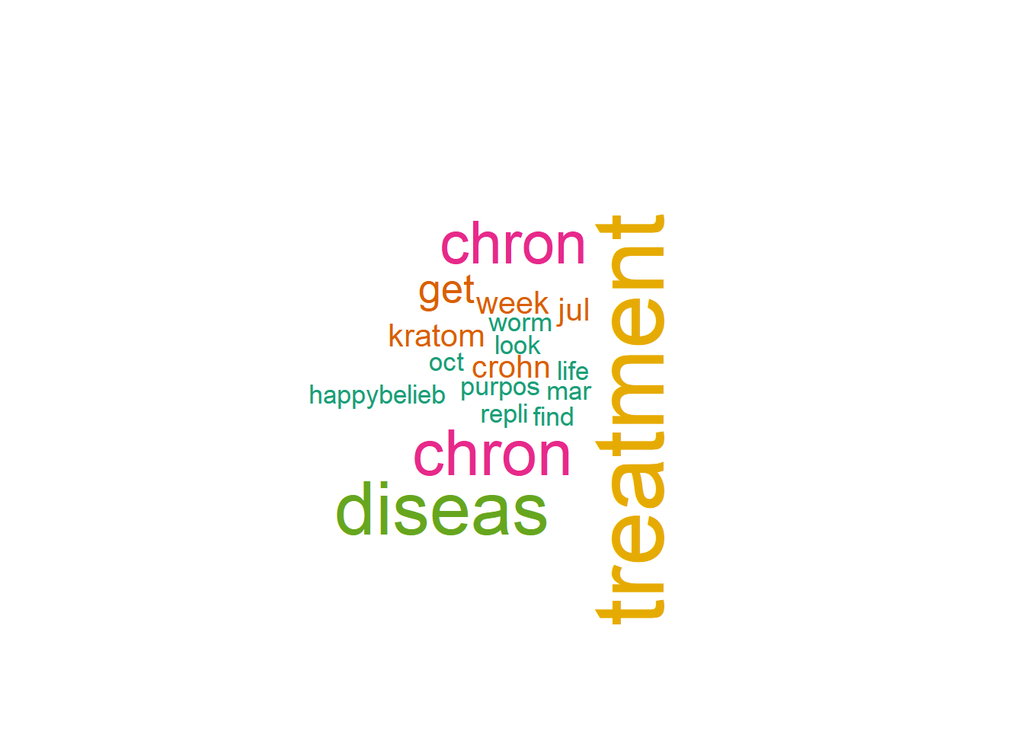

```r
wordcloud(names(freq), freq, max.words=40,colors=brewer.pal(6,'Dark2'))
```